# R Fundamentals Part3-4: ggplot2

D-Lab

March 31, 2019 (updated 2019-05-05)

# ggplot2

The “ggplot2” R package is an efficient way to visualize data and its syntax is easier to navigate than the base plotting functions. The [ggplot2](http://www.sthda.com/english/wiki/ggplot2-essentials) package is part of the [tidyverse](https://www.tidyverse.org/) - a series of R packages designed to simplify R syntax and functionality. “gg” stands for [“Grammar of Graphics.”](https://en.wikipedia.org/wiki/Leland_Wilkinson).

Although the package is called “ggplot2”, `ggplot` is the main function call. You need three things to create a ggplot:

1. a dataset - some data to be visualized.
2. “aes”thetics - definitions of your coordinate system, point color and shape mappings, etc.
3. geoms - how your data should be represented: points, bars, densities, ribbons, etc.

`ggplot` works in layers. Each time you wish to add a geom, title, axis label, or background color, you must add a new layer by typing the plus `+` sign at the end of the previous line.

Check out the help files:

```r
library(ggplot2)
?ggplot2
```

# ggplot histogram

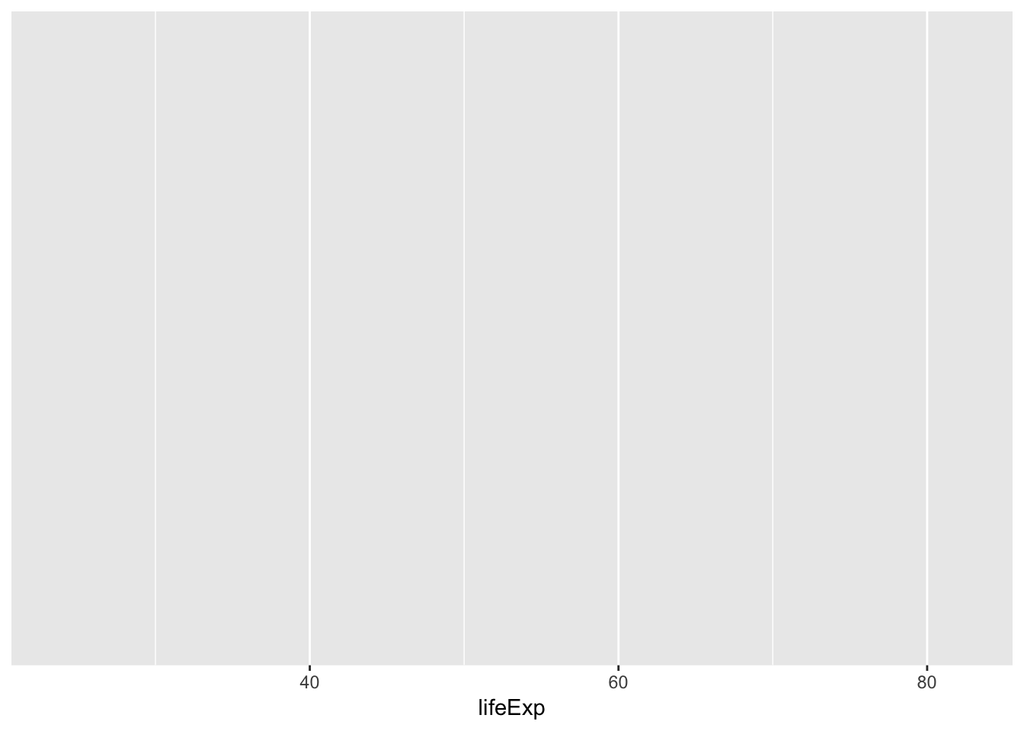

```r
load("../data-proc/data.RData")
ggplot(data = gap, aes(x = lifeExp))
```

We can add the bars by adding a new layer with `+`, and then specify “geom_histogram()” to produce the histogram!

To see the list of available geoms, type “geoms_” and press the `TAB` key.

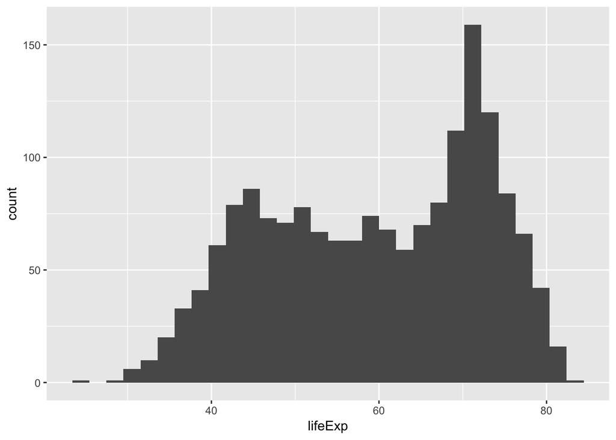

```r
ggplot(data = gap, aes(x = lifeExp)) +
    geom_histogram()
```

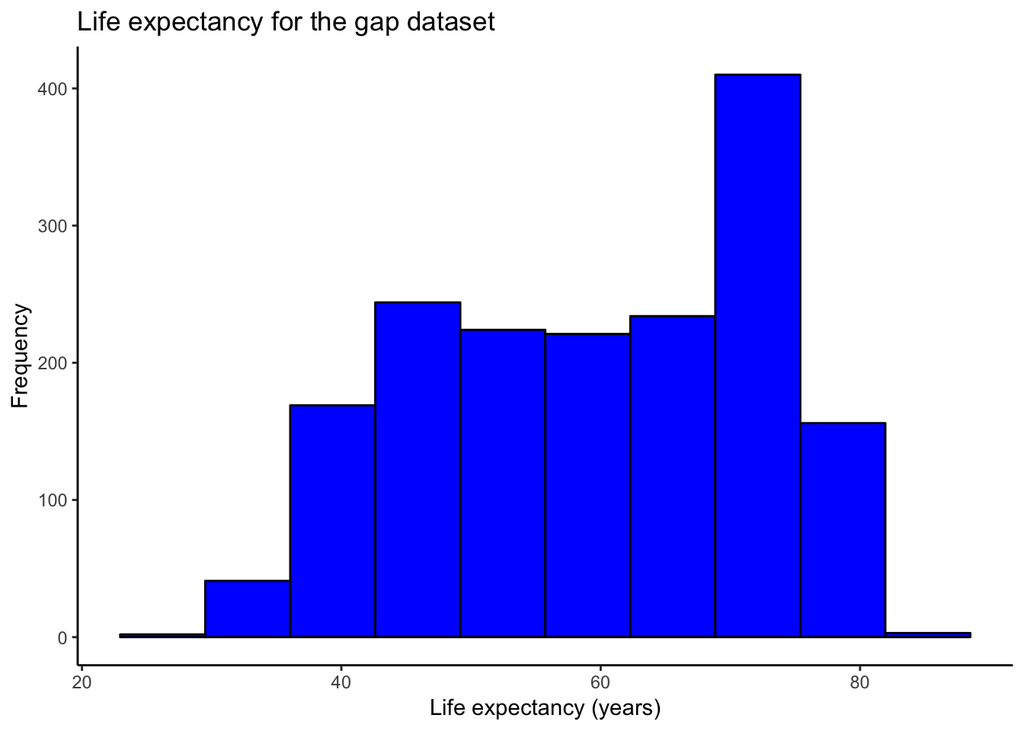

```r
ggplot(data = gap, aes(x = lifeExp)) +
  geom_histogram(fill = "blue", color = "black", bins = 10) +
  ggtitle("Life expectancy for the gap dataset") +
  xlab("Life expectancy (years)") +
  ylab("Frequency") +
  theme_classic()
```

# **Challenge 6**

1. Create a ggplot histogram of one of the variables from the sleep_VIM dataset.

```r
## YOUR CODE HERE
```

# ggplot boxplots

Boxplots continue to follow this logic. However, this time we should specifically define our X axis as the factor variable we wish to investigate, and the Y axis as some numeric value:

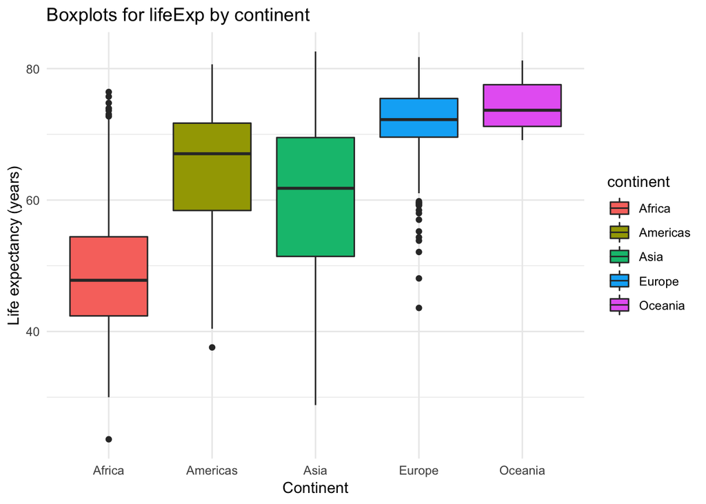

```r
ggplot(data = gap, aes(x = continent, y = lifeExp, fill = continent)) +
  geom_boxplot() +
  ggtitle("Boxplots for lifeExp by continent") +
  xlab("Continent") +
  ylab("Life expectancy (years)") +
  theme_minimal() # +
```

```r
  # guides(fill = FALSE)
```

What happens if you un-hashtage `guides(fill = FALSE)` and the plus sign in lines 68 and 69 above?

# **Challenge 7**

1. Create ggplot boxplots for 4, 6, and 8 cylinder cars from the mtcars dataset.

```r
## YOUR CODE HERE
```

# ggplot scatterplots

The other layer arguments apply as well. `size` will change the size of the points, while `alpha` will change their transparency.

We can also include a second `theme` argument layer where can can specify the legend position via `legend.position`.

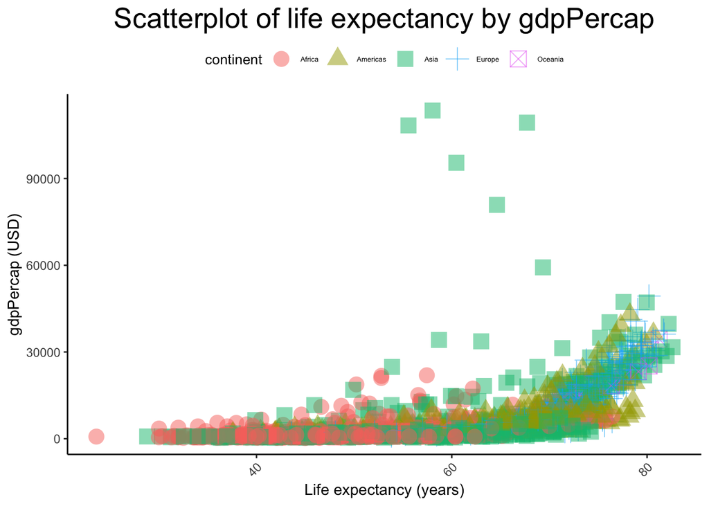

```r
ggplot(data = gap, aes(x = lifeExp, y = gdpPercap, color = continent, shape = continent)) +
    geom_point(size = 5, alpha = 0.5) +
    theme_classic() +
    ggtitle("Scatterplot of life expectancy by gdpPercap") +
    xlab("Life expectancy (years)") +
    ylab("gdpPercap (USD)") +
    theme(legend.position = "top",
          plot.title = element_text(hjust = 0.5, size = 20),
          legend.title = element_text(size = 10),
          legend.text = element_text(size = 5),
          axis.text.x = element_text(angle = 45, hjust = 1))
```

# **Challenge 8**

1. In lines the ggplot code above, what are the arguments inside of our second “theme” argument doing?

```r
##
```

There are many more additional arguments that you can use to tweak your ggplots. [Check out this cheatsheet to learn more!](https://www.rstudio.com/resources/cheatsheets/#ggplot2)